# report_2_stage

Работа на сервере

Рафи Кази ар, НКАбд-03-24

# 1 Цель работы

Ознакомиться с функционалом операционной системы Linux.

# 2 Задание

Просмотреть видео и на основе полученной информации пройти тестовые задания.

# 3 Выполнение лабораторной работы

2 Этап:

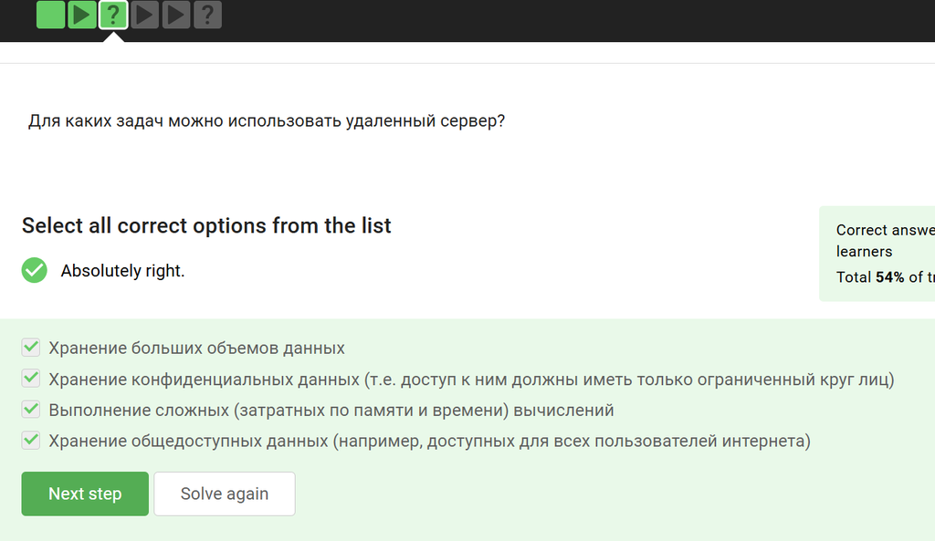

Рис. 1: Задание 1

Удаленный сервер - это компьютер, находящийся в дата-центре, к которому можно получить удаленный доступ через сеть Интернет.

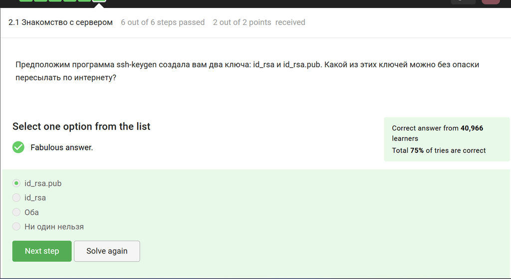

Рис. 2: Задание 2

Только id_rsa.pub, так как он является открытым.

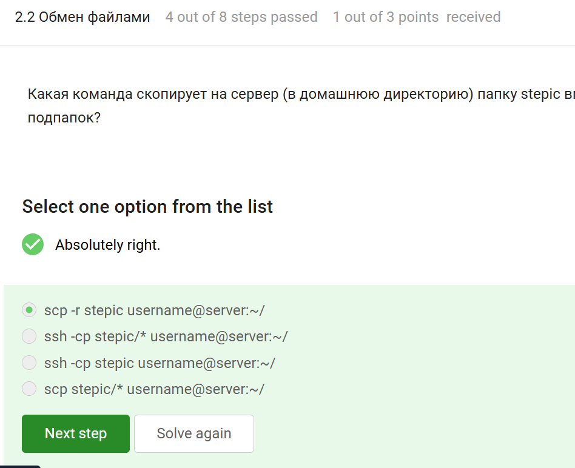

Рис. 3: Задание 3

-r = Recursively copy entire directories. Note that scp follows symbolic links encountered in the tree traversal.

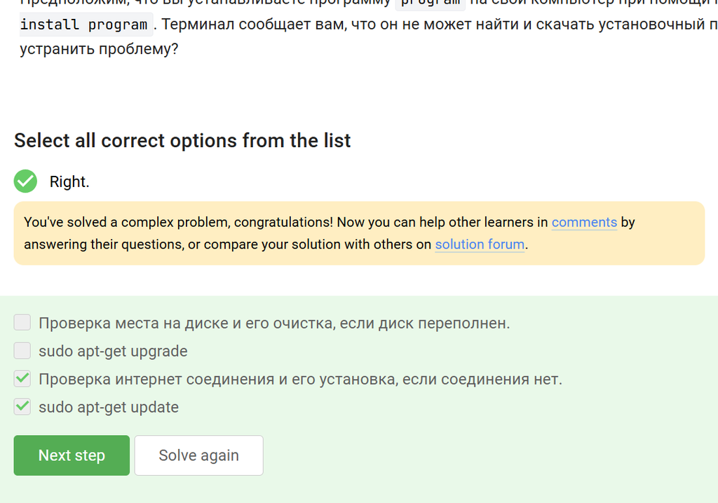

Рис. 4: Задание 4

Проверяем интернет соединение на предмет того, что устройство не может соединиться с сервером, затем проверяем то, знает ли оно вообще о существовании такой программы.

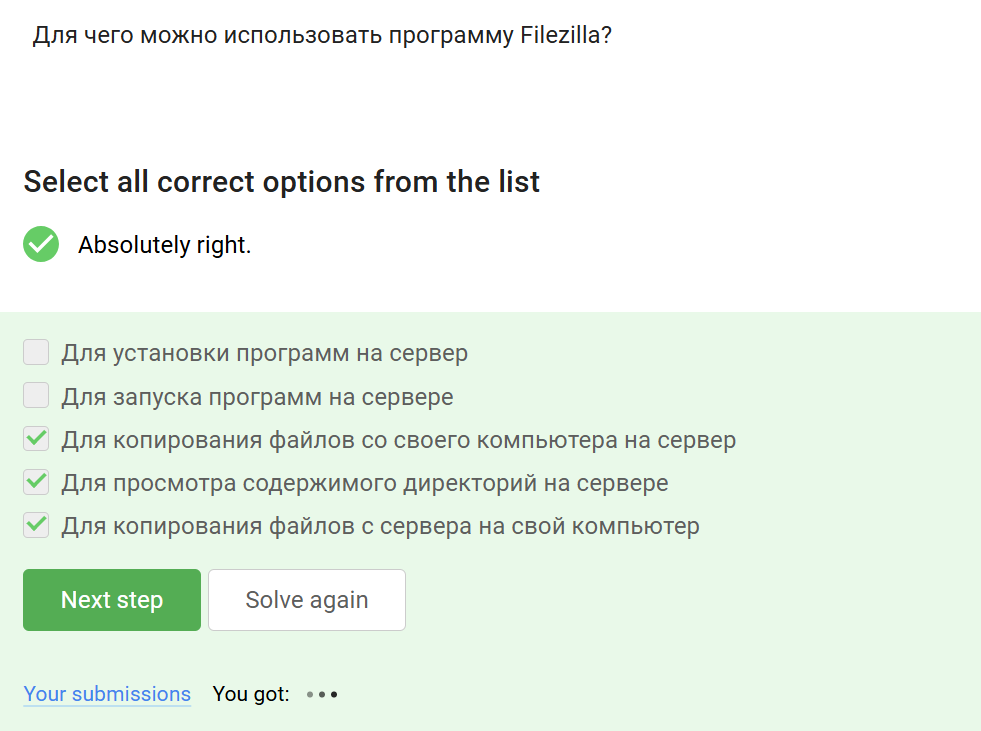

Рис. 5: Задание 5

FileZilla — свободный многоязычный проект, посвящённый приложениям для FTP.

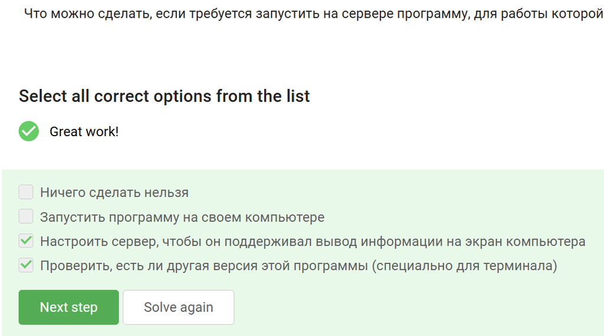

Рис. 6: Задание 6

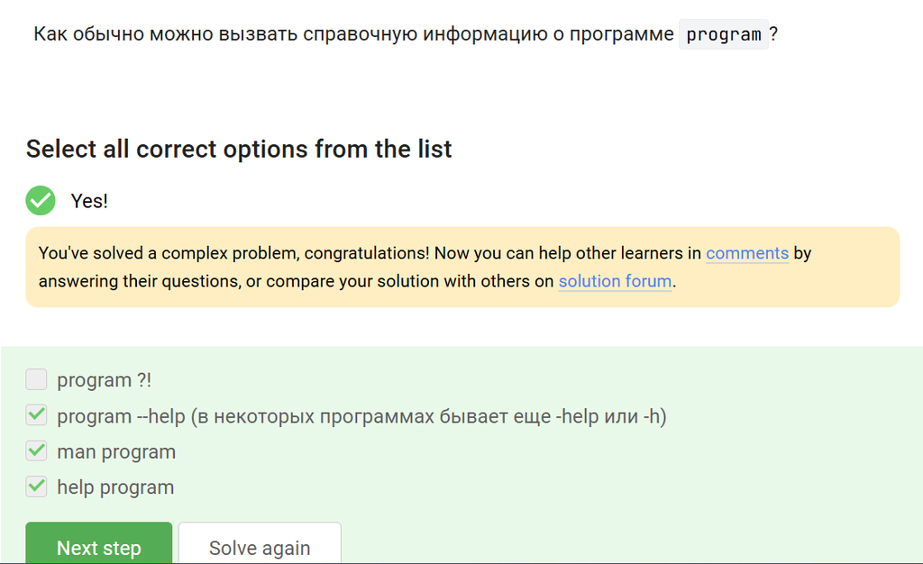

Рис. 7: Задание 7

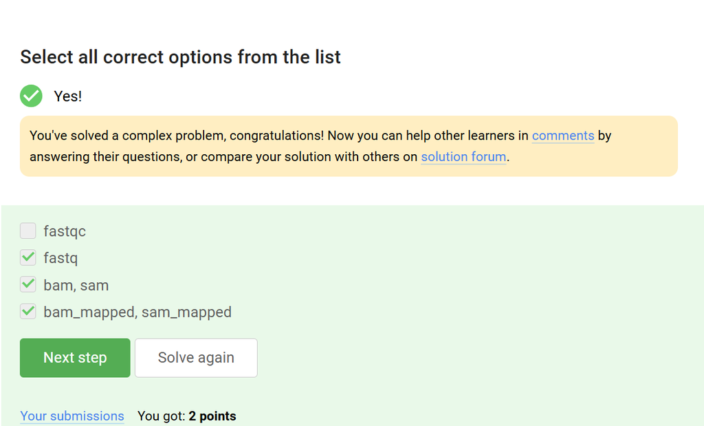

Рис. 8: Задание 8

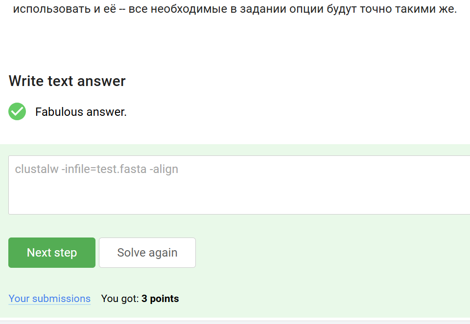

Рис. 9: Задание 9

-align Do full multiple alignment.

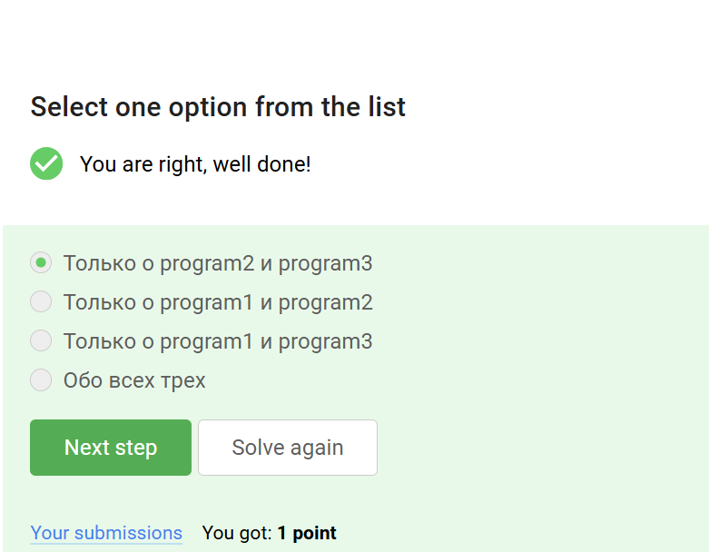

Рис. 10: Задание 10

Комбинация Ctrl+С - завершает процесс. Комбинация Ctrl+Z - приостанавливает процесс.

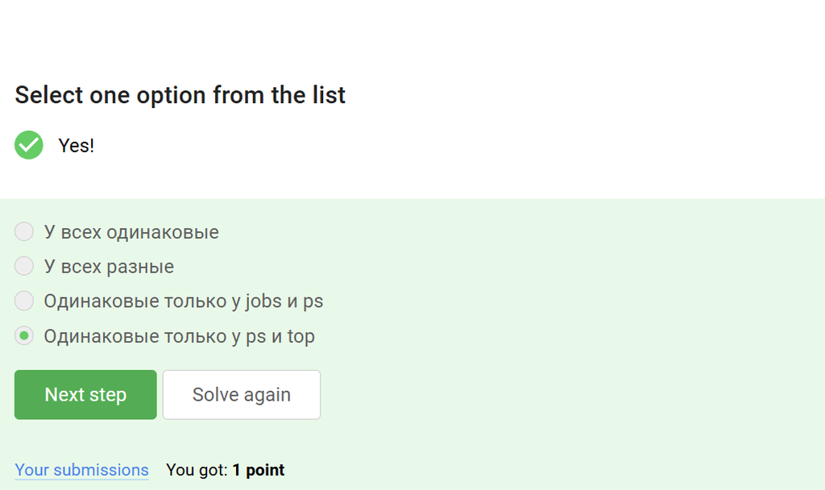

Рис. 11: Задание 11

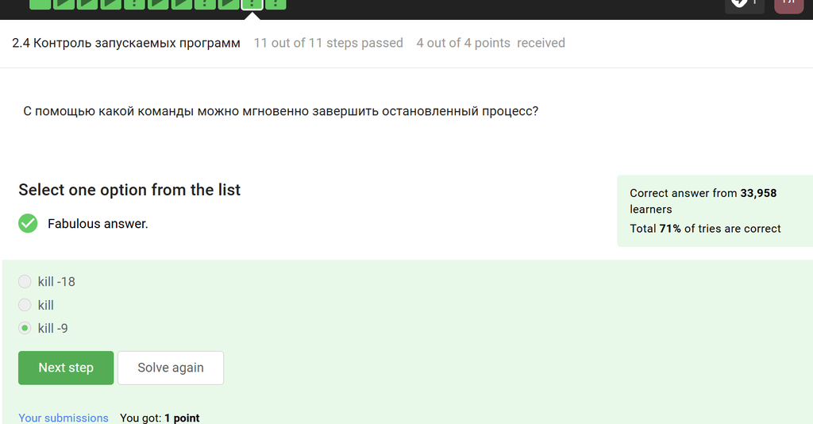

Рис. 12: Задание 12

Если сигнал не перехватывается процессом, процесс уничтожается. Следовательно, это используется для изящного завершения процесса. Команда «kill -9» отправляет сигнал уничтожения для немедленного завершения любого процесса, если он присоединен к PID или имени процесса . Это принудительный способ убить/завершить набор процессов

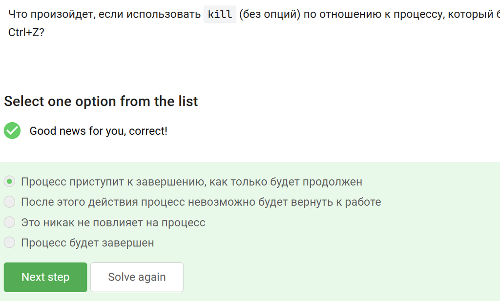

Рис. 13: Задание 13

Запущенная программа потребляет ресурсы CPU, а остановленная нет.

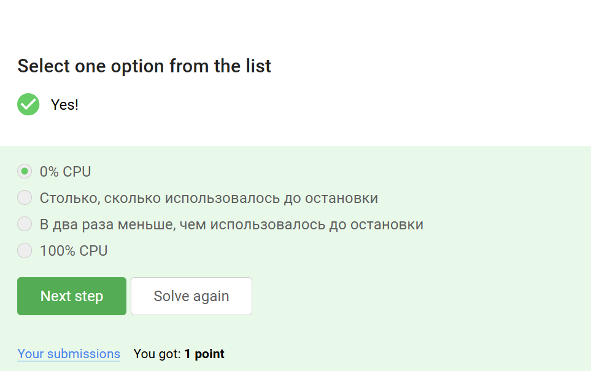

Рис. 14: Задание 15

Приостановленное приложение не выполняет новых действий, поэтому не занимает вычислительные ресурсы компьютера (CPU 0%).

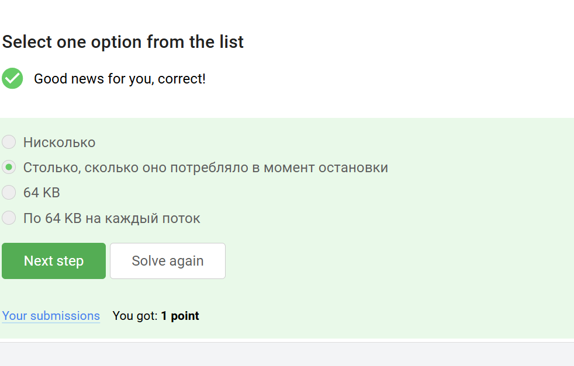

Рис. 15: Задание 16

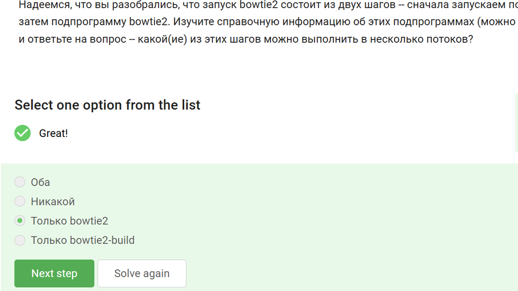

Рис. 16: Задание 17

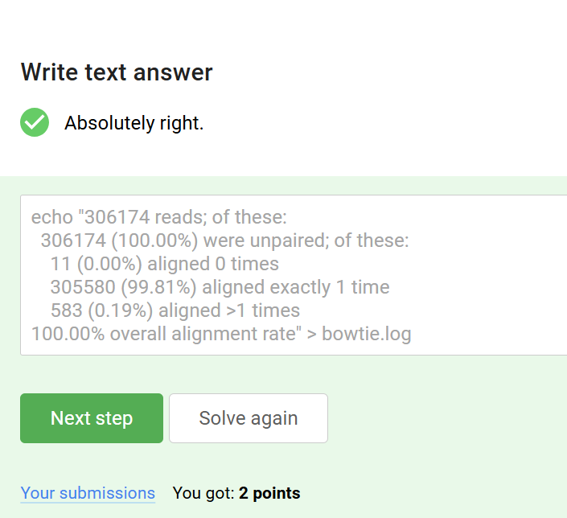

Рис. 17: Задание 18

```
echo "306174 reads; of these:
  306174 (100.00%) were unpaired; of these:
    11 (0.00%) aligned 0 times
    305580 (99.81%) aligned exactly 1 time
    583 (0.19%) aligned >1 times
100.00% overall alignment rate" > bowtie.log
```

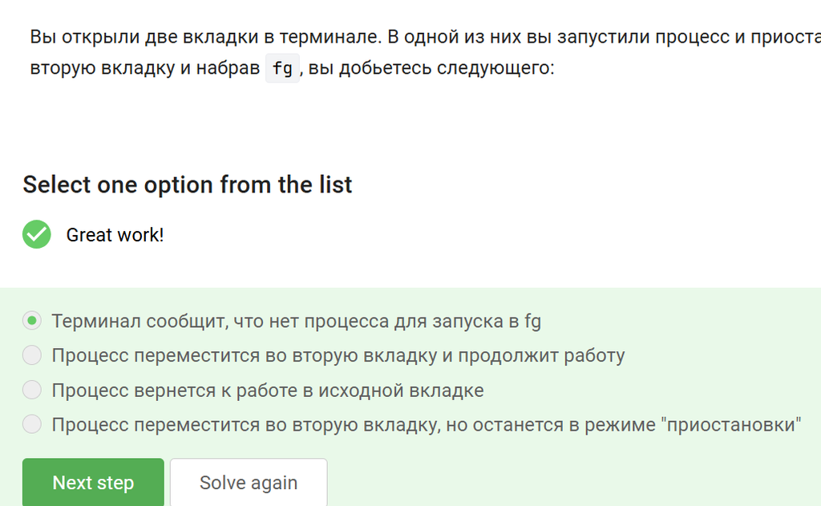

Рис. 18: Задание 19

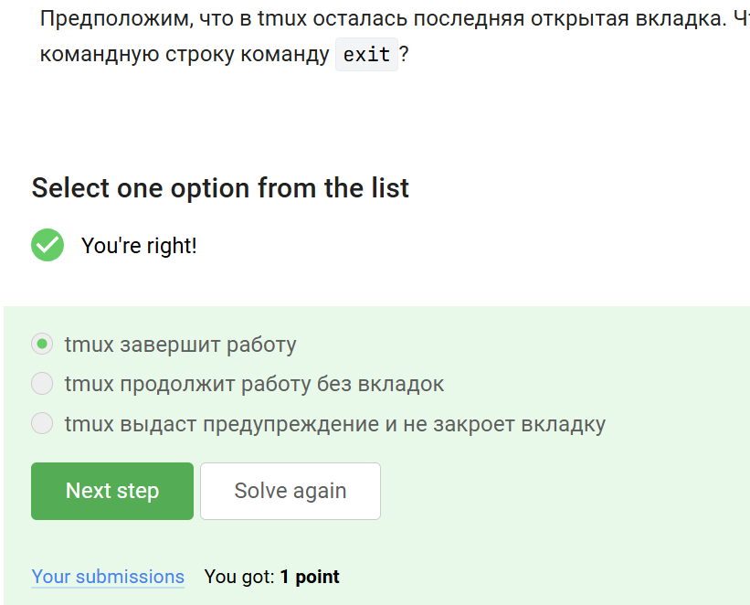

Рис. 19: Задание 20